# BDA507_COURSE PROJECT BY KAAN KARABAL

# VIDEO GAME SALES ANALYSIS

# 1.Introduction

I will review a dataset consists of several video games with some sales info, customer rating, platform and producer details. Dataset link is below for more detail; https://www.kaggle.com/rush4ratio/video-game-sales-with-ratings

My aim in this analysis will be to show which game platform desired more by players until today, through the analysis of sales amounts, released game quantities and userscores.

```python
# import of several libraries that will be used in project
import numpy as np
import pandas as pd
import pickle
import os
import math
import seaborn as sns
import matplotlib.pyplot as plt
%matplotlib inline
import warnings
warnings.filterwarnings('ignore')
```

In second step dataset will be imported and some generic functions will be run to have a general understanding of the data for further analysis such as type of data, categorical and numeric variable details, statistical distributions.

```python
# Import and read dataset
vgs_data = pd.read_csv("Video_Games_Sales_22122016.csv")

# Examine the data types of every variable
vgs_data.dtypes
```

```
Name                object
Platform            object
Year_of_Release    float64
Genre               object
Publisher           object
NA_Sales           float64
EU_Sales           float64
JP_Sales           float64
Other_Sales        float64
Global_Sales       float64
Critic_Score       float64
Critic_Count       float64
User_Score          object
User_Count         float64
Developer           object
Rating              object
dtype: object
```

```python
vgs_data.shape
```

```
(16719, 16)
```

```python
# Examine statistical details of non-categorical variables
vgs_data.describe()
```

|  | Year_of_Release | NA_Sales | EU_Sales | JP_Sales | Other_Sales | Global_Sales | Critic_Score | Critic_Count | User_Count |
| --- | --- | --- | --- | --- | --- | --- | --- | --- | --- |
| count | 16450.000000 | 16719.000000 | 16719.000000 | 16719.000000 | 16719.000000 | 16719.000000 | 8137.000000 | 8137.000000 | 7590.000000 |
| mean | 2006.487356 | 0.263330 | 0.145025 | 0.077602 | 0.047332 | 0.533543 | 68.967679 | 26.360821 | 162.229908 |
| std | 5.878995 | 0.813514 | 0.503283 | 0.308818 | 0.186710 | 1.547935 | 13.938165 | 18.980495 | 561.282326 |
| min | 1980.000000 | 0.000000 | 0.000000 | 0.000000 | 0.000000 | 0.010000 | 13.000000 | 3.000000 | 4.000000 |
| 25% | 2003.000000 | 0.000000 | 0.000000 | 0.000000 | 0.000000 | 0.060000 | 60.000000 | 12.000000 | 10.000000 |
| 50% | 2007.000000 | 0.080000 | 0.020000 | 0.000000 | 0.010000 | 0.170000 | 71.000000 | 21.000000 | 24.000000 |
| 75% | 2010.000000 | 0.240000 | 0.110000 | 0.040000 | 0.030000 | 0.470000 | 79.000000 | 36.000000 | 81.000000 |
| max | 2020.000000 | 41.360000 | 28.960000 | 10.220000 | 10.570000 | 82.530000 | 98.000000 | 113.000000 | 10665.000000 |

```python
# Examine the details of categorical variables
categorical = vgs_data.dtypes[vgs_data.dtypes == "object"].index
print(categorical)

vgs_data[categorical].describe()
```

```
Index(['Name', 'Platform', 'Genre', 'Publisher', 'User_Score', 'Developer',
       'Rating'],
      dtype='object')
```

|  | Name | Platform | Genre | Publisher | User_Score | Developer | Rating |
| --- | --- | --- | --- | --- | --- | --- | --- |
| count | 16717 | 16719 | 16717 | 16665 | 10015 | 10096 | 9950 |
| unique | 11562 | 31 | 12 | 581 | 96 | 1696 | 8 |
| top | Need for Speed: Most Wanted | PS2 | Action | Electronic Arts | tbd | Ubisoft | E |
| freq | 12 | 2161 | 3370 | 1356 | 2425 | 204 | 3991 |

## 2.Data Cleaning

Before I start with the visualization and going deeper in my analysis through the dataset, it will be usefull to go through statiscal information of dataset to learn about the details.

First, null values will be controlled in the data;

```python
vgs_data.isnull().any().count()
vgs_data.isnull().sum()
```

```
Name                  2
Platform              0
Year_of_Release     269
Genre                 2
Publisher            54
NA_Sales              0
EU_Sales              0
JP_Sales              0
Other_Sales           0
Global_Sales          0
Critic_Score       8582
Critic_Count       8582
User_Score         6704
User_Count         9129
Developer          6623
Rating             6769
dtype: int64
```

According to null value check, null values generally seems in the columns which I am not planning to use in my analysis. That's why I am going to get rid of all these null values instead of filling them with mean, median or any other type of generic data.

```python
vgs_data = vgs_data.dropna(axis=0)
```

Year_of_Release information should be represented as an object for further use, that's why dtype of this column converted to the object.

```python
# Convert "Year of Release" variable to an object
vgs_data['Year_of_Release'] = vgs_data['Year_of_Release'].astype(object)
vgs_data['Year_of_Release'].head()
```

```
0    2006
2    2008
3    2009
6    2006
7    2006
Name: Year_of_Release, dtype: object
```

According to unique variables of "Platform" it will be useful to add one more "Platform_General" colums to group some of these platform types under larger groups such PS,PS3 and PS4 under Playstation and X360,XB and Xone under Xbox categories. I expect this categorization will led me to perform comparisons between two biggest game platforms.

After I create Platform_General column, group 3 main console brand under same name as Playstation, Nintendo and Microsoft(XBox)

```python
# Check uniq values of Platform
vgs_data["Platform"].unique()
```

```
array(['Wii', 'DS', 'X360', 'PS3', 'PS2', '3DS', 'PS4', 'PS', 'XB', 'PC',
       'PSP', 'WiiU', 'GC', 'GBA', 'XOne', 'PSV', 'DC'], dtype=object)
```

```python
# Copy and add one more platform column to the end of dataset
vgs_data['Platform_General']= vgs_data['Platform']

#Convert console subnames to the general names
vgs_data.loc[vgs_data['Platform'] == 'PS3', 'Platform_General'] = 'Sony_Playstation'
vgs_data.loc[vgs_data['Platform'] == 'PS', 'Platform_General'] = 'Sony_Playstation'
vgs_data.loc[vgs_data['Platform'] == 'PS2', 'Platform_General'] = 'Sony_Playstation'
vgs_data.loc[vgs_data['Platform'] == 'PS4', 'Platform_General'] = 'Sony_Playstation'
vgs_data.loc[vgs_data['Platform'] == 'PSP', 'Platform_General'] = 'Sony_Playstation'
vgs_data.loc[vgs_data['Platform'] == 'PSV', 'Platform_General'] = 'Sony_Playstation'
vgs_data.loc[vgs_data['Platform'] == 'Wii', 'Platform_General'] = 'Nintendo'
vgs_data.loc[vgs_data['Platform'] == 'DS', 'Platform_General'] = 'Nintendo'
vgs_data.loc[vgs_data['Platform'] == 'GBA', 'Platform_General'] = 'Nintendo'
vgs_data.loc[vgs_data['Platform'] == '3DS', 'Platform_General'] = 'Nintendo'
vgs_data.loc[vgs_data['Platform'] == 'WiiU', 'Platform_General'] = 'Nintendo'
vgs_data.loc[vgs_data['Platform'] == 'NES', 'Platform_General'] = 'Nintendo'
vgs_data.loc[vgs_data['Platform'] == 'SNES', 'Platform_General'] = 'Nintendo'
vgs_data.loc[vgs_data['Platform'] == 'N64', 'Platform_General'] = 'Nintendo'
vgs_data.loc[vgs_data['Platform'] == 'GB', 'Platform_General'] = 'Nintendo'
vgs_data.loc[vgs_data['Platform'] == 'GC', 'Platform_General'] = 'Nintendo'
vgs_data.loc[vgs_data['Platform'] == 'X360', 'Platform_General'] = 'Microsoft_Xbox'
vgs_data.loc[vgs_data['Platform'] == 'XB', 'Platform_General'] = 'Microsoft_Xbox'
vgs_data.loc[vgs_data['Platform'] == 'XOne', 'Platform_General'] = 'Microsoft_Xbox'
vgs_data.loc[vgs_data['Platform'] == '2600', 'Platform_General'] = 'Atari'
vgs_data.loc[vgs_data['Platform'] == 'DC', 'Platform_General'] = 'Sega'
vgs_data.loc[vgs_data['Platform'] == 'SAT', 'Platform_General'] = 'Sega'
vgs_data.loc[vgs_data['Platform'] == 'GG', 'Platform_General'] = 'Sega'
vgs_data.loc[vgs_data['Platform'] == 'WS', 'Platform_General'] = 'Bandal'
vgs_data.loc[vgs_data['Platform'] == 'TG16', 'Platform_General'] = 'Nec'
vgs_data.loc[vgs_data['Platform'] == 'PCFX', 'Platform_General'] = 'Nec'
vgs_data.loc[vgs_data['Platform'] == '3DO', 'Platform_General'] = 'Panasonic'

# Check uniq values of Platform_General
vgs_data["Platform_General"].unique()
```

```
array(['Nintendo', 'Microsoft_Xbox', 'Sony_Playstation', 'PC', 'Sega'], dtype=object)
```

## 3.Generic Data Analysis

As a start to my analysis through out the data I would like to see how game industry evolved based on the count of the games published in every year between 1980 & 2017.

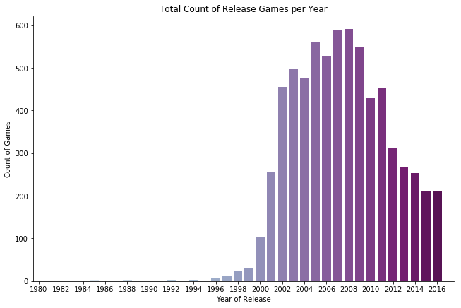

```python
years =np.arange(1980,2018)

game_count_year = sns.factorplot(x="Year_of_Release", data=vgs_data, kind="count",
                   palette="BuPu", size=6, aspect=1.5, order=years)
game_count_year.set_xticklabels(step=2)
game_count_year.set(xlabel = 'Year of Release',ylabel = 'Count of Games',title = 'Total Count of Release Games per Year')
```

To dig into details, first I will go through the platform distribution of released games per year and global sales per year between 1994 - 2017. To do this, first I will check for all platforms and after that I will pick top three platforms to continue my detailed analysis.

According to below graph Sony Playstation, Microsoft Xbox & Nintendo dominates the market in terms of published and sold game quantities.

```
Text(0.5,0,'Year of Release')
```

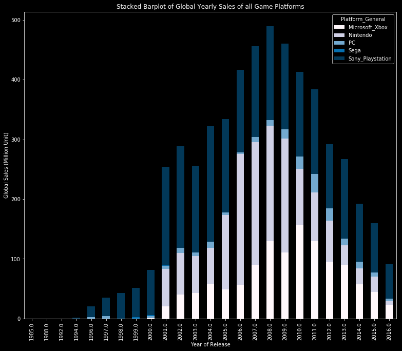

```python
plt.style.use('dark_background')
yearlySales = vgs_data.groupby(['Year_of_Release','Platform_General']).Global_Sales.sum()
yearlySales.unstack().plot(kind='bar',stacked=True, colormap= 'PuBu',
                           grid=False,  figsize=(13,11))
plt.title('Stacked Barplot of Global Yearly Sales of all Game Platforms')
plt.ylabel('Global Sales (Million Unit)')
plt.xlabel('Year of Release')
```

## 4.Top 3 Console Comparison

From this point I will continue my detail analysis through these three platforms only. To perform this I will create a dataset that contains information of these selected game consoles.

First of all I will make the statistical analysis of dataset to define outliers or any other possible data that may affect the solution of my analysis.

```
4.1. Statistical Analysis
```

Afterwards I will compare these three platform details according to below areas;

```
4.2. Trend of global sales amount per year / games released per year
4.3. Critic Scores comparison between platforms
4.4. Genre distribution of games
```

### 4.1.Statistical Analysis

Because of I decide to analyse only top 3 platforms first I create a subset of Sony_Playstation, Microsoft_Xbox and Nintendo to analyse.

```python
vgs_data_platform = vgs_data[(vgs_data['Platform_General'] == 'Sony_Playstation') |
                             (vgs_data['Platform_General'] == 'Microsoft_Xbox') |
                             (vgs_data['Platform_General'] == 'Nintendo')]

vgs_data_platform['dummy_count'] = '1'
vgs_data_platform['dummy_count'] = vgs_data_platform['dummy_count'].astype(float)
vgs_data_platform['User_Score'] = vgs_data_platform['User_Score'].astype(float)
vgs_data_platform.describe()
```

|  | NA_Sales | EU_Sales | JP_Sales | Other_Sales | Global_Sales | Critic_Score | Critic_Count | User_Score | User_Count | dummy_count |
| --- | --- | --- | --- | --- | --- | --- | --- | --- | --- | --- |
| count | 6160.000000 | 6160.000000 | 6160.000000 | 6160.000000 | 6160.000000 | 6160.000000 | 6160.000000 | 6160.000000 | 6160.000000 | 6160.0 |
| mean | 0.426469 | 0.244513 | 0.070625 | 0.088703 | 0.830419 | 69.600325 | 28.979383 | 7.195812 | 119.513961 | 1.0 |
| std | 1.006861 | 0.708645 | 0.301780 | 0.282232 | 2.047041 | 13.971186 | 19.397787 | 1.429799 | 417.314998 | 0.0 |
| min | 0.000000 | 0.000000 | 0.000000 | 0.000000 | 0.010000 | 13.000000 | 3.000000 | 0.500000 | 4.000000 | 1.0 |
| 25% | 0.080000 | 0.020000 | 0.000000 | 0.010000 | 0.130000 | 61.000000 | 14.000000 | 6.500000 | 10.000000 | 1.0 |
| 50% | 0.170000 | 0.060000 | 0.000000 | 0.030000 | 0.330000 | 72.000000 | 25.000000 | 7.500000 | 23.000000 | 1.0 |
| 75% | 0.430000 | 0.220000 | 0.020000 | 0.080000 | 0.820000 | 80.000000 | 39.000000 | 8.200000 | 69.000000 | 1.0 |
| max | 41.360000 | 28.960000 | 6.500000 | 10.570000 | 82.530000 | 98.000000 | 113.000000 | 9.600000 | 10179.000000 | 1.0 |

Now, lets check the statistical details of Global_Sales quantities. When we check the above details its obvious that there are some outliers because of the difference between mean (0,83) & median (0,33) of Global_Sales variable.

```python
vgs_data_platform['Global_Sales'].quantile([0,0.01, 0.25, 0.5, 0.75, 0.95, 1])
```

```
0.00     0.0100
0.01     0.0200
0.25     0.1300
0.50     0.3300
0.75     0.8200
0.95     3.0105
1.00    82.5300
Name: Global_Sales, dtype: float64
```

```python
vgs_data_platform = vgs_data_platform[vgs_data_platform.Global_Sales < vgs_data_platform.Global_Sales.quantile(.95)]

vgs_data_platform['Global_Sales'].quantile([0,0.01, 0.25, 0.5, 0.75, 0.95, 1])
```

```
0.00    0.01
0.01    0.02
0.25    0.13
0.50    0.30
0.75    0.70
0.95    1.86
1.00    3.01
Name: Global_Sales, dtype: float64
```

### 4.2.Trend of global sales amount per year / games released per year

First I would like to see correlation between the number of games released per year and global sales amount according to game platforms. To be able to do this analysis I need to create subset including sales per game in terms of platforms.

```python
# First group by the data
vdpg = vgs_data_platform.groupby(['Year_of_Release', 'Platform_General','Platform'])
# Second add counts according to group_by info and then join with the statistical information required
counts = vdpg.size().to_frame(name='counts')
vgs_df_pf_grouped = (counts
.join(vdpg.agg({'Global_Sales': 'sum'}).rename(columns={'Global_Sales': 'Global_Sales(M#)'}))
.reset_index()
)

vgs_df_pf_grouped['GS_Amount_per_Game'] = vgs_df_pf_grouped['Global_Sales(M#)']/vgs_df_pf_grouped['counts']
vgs_df_pf_grouped = vgs_df_pf_grouped.convert_objects(convert_numeric=True)
```

I will check the descriptive statistics of each platform seperately before visualization.

Below tables have been created for Sony_Playstation, Microsoft_Xbox and nintendo respectively.

```python
vgs_df_pf_grouped[(vgs_df_pf_grouped['Platform_General']=='Sony_Playstation')].describe()
```

|  | Year_of_Release | counts | Global_Sales(M#) | GS_Amount_per_Game |
| --- | --- | --- | --- | --- |
| count | 48.000000 | 48.000000 | 48.000000 | 48.000000 |
| mean | 2007.479167 | 55.083333 | 31.262500 | 0.545623 |
| std | 5.786961 | 51.544995 | 32.331395 | 0.280213 |
| min | 1994.000000 | 1.000000 | 0.020000 | 0.020000 |
| 25% | 2003.750000 | 12.750000 | 5.097500 | 0.370187 |
| 50% | 2008.000000 | 38.500000 | 19.050000 | 0.546404 |
| 75% | 2012.250000 | 87.250000 | 45.830000 | 0.682222 |
| max | 2016.000000 | 191.000000 | 120.400000 | 1.356923 |

```python
vgs_df_pf_grouped[(vgs_df_pf_grouped['Platform_General']=='Microsoft_Xbox')].describe()
```

|  | Year_of_Release | counts | Global_Sales(M#) | GS_Amount_per_Game |
| --- | --- | --- | --- | --- |
| count | 22.000000 | 22.000000 | 22.000000 | 22.000000 |
| mean | 2008.227273 | 68.863636 | 35.737273 | 0.551475 |
| std | 4.790187 | 45.437865 | 24.729521 | 0.227895 |
| min | 2000.000000 | 1.000000 | 0.550000 | 0.183333 |
| 25% | 2005.000000 | 29.000000 | 14.420000 | 0.390407 |
| 50% | 2007.500000 | 64.500000 | 37.250000 | 0.547944 |
| 75% | 2012.750000 | 112.250000 | 52.902500 | 0.686163 |
| max | 2016.000000 | 133.000000 | 79.020000 | 1.064286 |

```python
vgs_df_pf_grouped[(vgs_df_pf_grouped['Platform_General']=='Nintendo')].describe()
```

|  | Year_of_Release | counts | Global_Sales(M#) | GS_Amount_per_Game |
| --- | --- | --- | --- | --- |
| count | 40.000000 | 40.000000 | 40.000000 | 40.000000 |
| mean | 2008.375000 | 42.325000 | 19.921000 | 0.485024 |
| std | 4.406798 | 33.933863 | 16.880217 | 0.196187 |
| min | 2001.000000 | 1.000000 | 0.220000 | 0.110000 |
| 25% | 2005.000000 | 17.000000 | 7.525000 | 0.371885 |
| 50% | 2008.000000 | 30.500000 | 17.875000 | 0.454232 |
| 75% | 2012.000000 | 59.000000 | 28.395000 | 0.562500 |
| max | 2016.000000 | 121.000000 | 71.200000 | 1.113333 |

In below graph I visualized the statistical information above to support my hypothesis about the Sony_Playstation global sales count per game ratio.

In these graphs it can be seen that Nintendo and Xbox have more straightforward trend while Playstation has a decreasing trend for sales per game ratio.

We can make some assumptions regarding to Playstations trend which are;

```
Text(0.5,1.05,'GLOBAL SALES PER GAME FOR EACH PLATFORM')
```

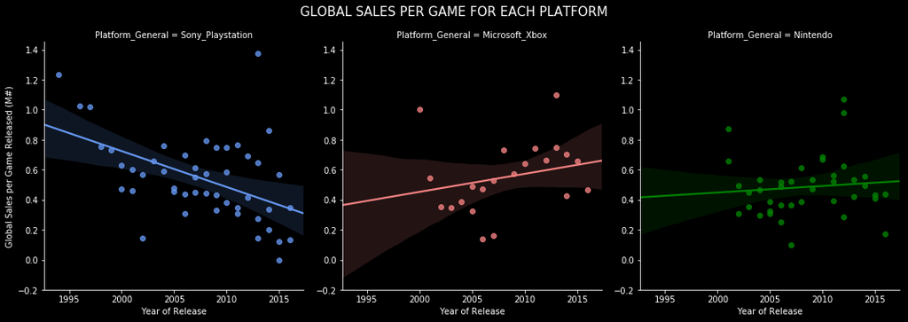

```python
# Make a custom palette with platform colors
pal = dict(Sony_Playstation="#6495ED", Microsoft_Xbox="#F08080",Nintendo="Green")

# Show the survival proability as a function of platforms
g = sns.lmplot(x="Year_of_Release", y="GS_Amount_per_Game", col="Platform_General", hue="Platform_General",
               data=vgs_df_pf_grouped,palette=pal, y_jitter=.05)

# Use more informative axis labels than are provided by default
g.set_axis_labels("Year of Release", "Global Sales per Game Released (M#)")
g.fig.suptitle("GLOBAL SALES PER GAME FOR EACH PLATFORM",fontsize = 15, y = 1.05)
```

```
Text(0.5,1.05,'GLOBAL GAME SALES PER YEAR FOR EACH PLATFORM')
```

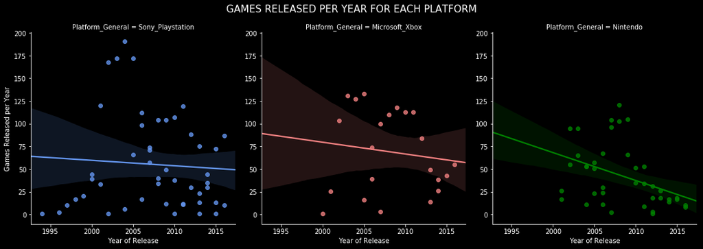

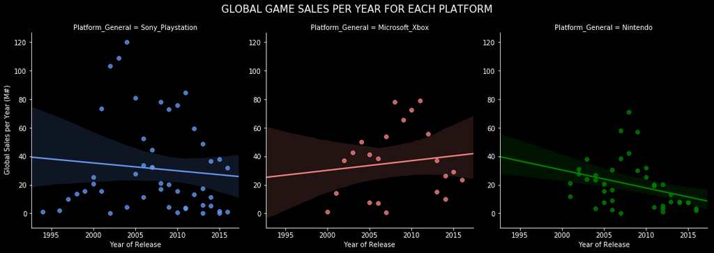

```python
# Make a custom palette with platform colors
pal = dict(Sony_Playstation="#6495ED", Microsoft_Xbox="#F08080",Nintendo="Green")

# Show the survival proability as a function of platforms
g = sns.lmplot(x="Year_of_Release", y="counts", col="Platform_General", hue="Platform_General",
               data=vgs_df_pf_grouped,palette=pal, y_jitter=.05)

# Use more informative axis labels than are provided by default
g.set_axis_labels("Year of Release", "Games Released per Year")
g.fig.suptitle("GAMES RELEASED PER YEAR FOR EACH PLATFORM",fontsize = 15, y = 1.05)

# Make a custom palette with platform colors
pal = dict(Sony_Playstation="#6495ED", Microsoft_Xbox="#F08080",Nintendo="Green")

# Show the survival proability as a function of platforms
g = sns.lmplot(x="Year_of_Release", y="Global_Sales(M#)", col="Platform_General", hue="Platform_General",
               data=vgs_df_pf_grouped,palette=pal, y_jitter=.05)

# Use more informative axis labels than are provided by default
g.set_axis_labels("Year of Release", " Global Sales per Year (M#)")
g.fig.suptitle("GLOBAL GAME SALES PER YEAR FOR EACH PLATFORM",fontsize = 15, y = 1.05)
```

### 4.3. Critic Scores comparison between platforms

For specific cases we encounter some outliers but they won't be changing the result

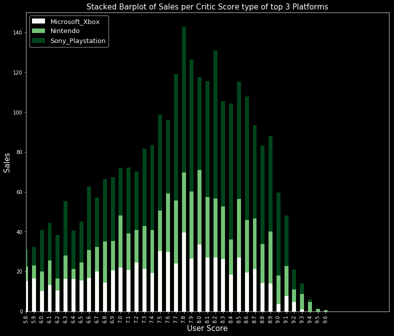

```python
plt.style.use('dark_background')
ratingSales = vgs_data_platform.groupby(['User_Score','Platform_General']).Global_Sales.sum()
ratingSales.unstack().plot(kind='bar',stacked=True,  colormap= 'Greens',
                           grid=False, figsize=(13,11))
plt.title('Stacked Barplot of Sales per Critic Score type of top 3 Platforms',fontsize=15)
plt.ylabel('Sales',fontsize =15)
plt.xlabel('User Score',fontsize = 15)
plt.xlim(50,96)
plt.legend(loc=2, prop={'size': 13})
```

### 4.4. Genre distribution of games

Genre distribution of games in different console types can be seen in below pie charts.

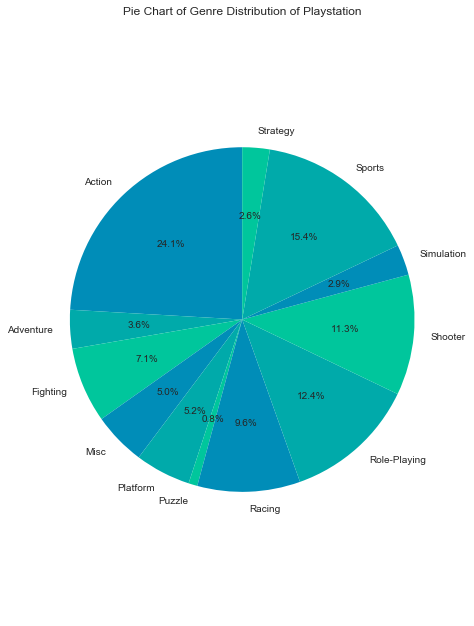

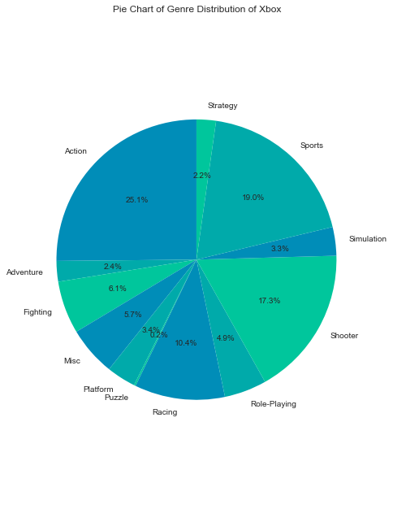

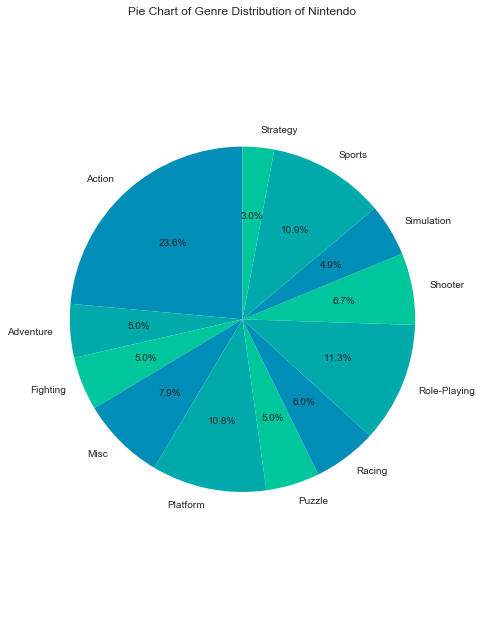

```python
plt.style.use('seaborn-white')
colors = ['#008DB8','#00AAAA','#00C69C']
plt.figure(figsize=(15,11))
plt.subplot(121)
plt.pie(
   vgs_data_platform[(vgs_data_platform['Platform_General']=='Sony_Playstation')].groupby('Genre').dummy_count.sum(),
    # with the labels being platform
    labels=vgs_data_platform.groupby('Genre').dummy_count.sum().index,
    # with no shadows
    shadow=False,
    # stating our colors
    colors=colors,
    # with the start angle at 90%
    startangle=90,
    # with the percent listed as a fraction
    autopct='%1.1f%%'
    )
plt.axis('equal')
plt.title('Pie Chart of Genre Distribution of Playstation')

plt.style.use('seaborn-white')
colors = ['#008DB8','#00AAAA','#00C69C']
plt.figure(figsize=(15,11))
plt.subplot(122)
plt.pie(
   vgs_data_platform[(vgs_data_platform['Platform_General']=='Microsoft_Xbox')].groupby('Genre').dummy_count.sum(),
    # with the labels being platform
    labels=vgs_data_platform.groupby('Genre').dummy_count.sum().index,
    # with no shadows
    shadow=False,
    # stating our colors
    colors=colors,
    # with the start angle at 90%
    startangle=90,
    # with the percent listed as a fraction
    autopct='%1.1f%%'
    )
plt.axis('equal')
plt.title('Pie Chart of Genre Distribution of Xbox')

plt.style.use('seaborn-white')
colors = ['#008DB8','#00AAAA','#00C69C']
plt.figure(figsize=(15,11))
plt.subplot(122)
plt.pie(
   vgs_data_platform[(vgs_data_platform['Platform_General']=='Nintendo')].groupby('Genre').dummy_count.sum(),
    # with the labels being platform
    labels=vgs_data_platform.groupby('Genre').dummy_count.sum().index,
    # with no shadows
    shadow=False,
    # stating our colors
    colors=colors,
    # with the start angle at 90%
    startangle=90,
    # with the percent listed as a fraction
    autopct='%1.1f%%'
    )
plt.axis('equal')
plt.title('Pie Chart of Genre Distribution of Nintendo')
plt.show()
```

## 5. Conclusion

And as I said this analysis have been done according to data initiated from 1990's. If I had my analysis for last 10 years, numbers will probably change but Sony_Playstation will most probable keep its position as market leader.